# Labs 3-4

Dylan Maddux

2023-09-04

```r
library("ggplot2")
## In ggplot2 it is stored as a different object so we convert to data.frame first
mpg <- as.data.frame(mpg)
head(mpg)
```

```
##   manufacturer model displ year cyl      trans drv cty hwy fl   class
## 1         audi    a4   1.8 1999   4   auto(l5)   f  18  29  p compact
## 2         audi    a4   1.8 1999   4 manual(m5)   f  21  29  p compact
## 3         audi    a4   2.0 2008   4 manual(m6)   f  20  31  p compact
## 4         audi    a4   2.0 2008   4   auto(av)   f  21  30  p compact
## 5         audi    a4   2.8 1999   6   auto(l5)   f  16  26  p compact
## 6         audi    a4   2.8 1999   6 manual(m5)   f  18  26  p compact
```

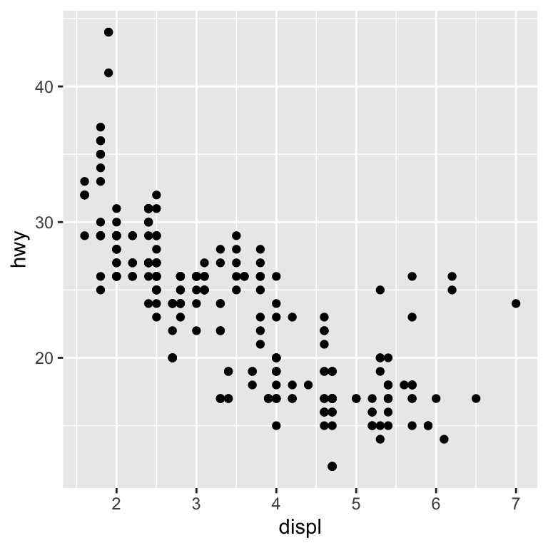

```r
ggplot(mpg, aes(displ, hwy)) +
  geom_point()
```

## Question 1:

Identify the three components that were needed to produce the scatter plot above, namely the data, the aesthetics, and the layers.

- The mpg data that we pulled from the default r data.
- The x and y axis labels from aes()
- The layer is literally the scatterplot data

## Question 2

Use geom_boxplot() to create a box plot with the mpg data with the class variable on the x-axis and hwy on the y-axis.

```r
mpg <- as.data.frame(mpg)
head(mpg)
```

```
##   manufacturer model displ year cyl      trans drv cty hwy fl   class
## 1         audi    a4   1.8 1999   4   auto(l5)   f  18  29  p compact
## 2         audi    a4   1.8 1999   4 manual(m5)   f  21  29  p compact
## 3         audi    a4   2.0 2008   4 manual(m6)   f  20  31  p compact
## 4         audi    a4   2.0 2008   4   auto(av)   f  21  30  p compact
## 5         audi    a4   2.8 1999   6   auto(l5)   f  16  26  p compact
## 6         audi    a4   2.8 1999   6 manual(m5)   f  18  26  p compact
```

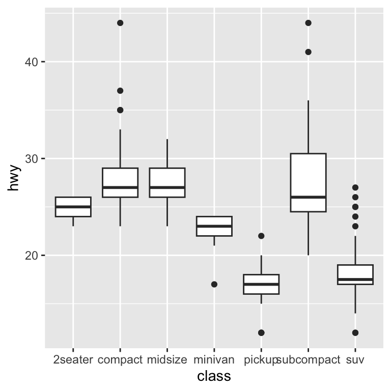

```r
ggplot(mpg, aes(class, hwy)) +
  geom_boxplot()
```

## Question 3

```r
mpg <- as.data.frame(mpg)
head(mpg)
```

```
##   manufacturer model displ year cyl      trans drv cty hwy fl   class
## 1         audi    a4   1.8 1999   4   auto(l5)   f  18  29  p compact
## 2         audi    a4   1.8 1999   4 manual(m5)   f  21  29  p compact
## 3         audi    a4   2.0 2008   4 manual(m6)   f  20  31  p compact
## 4         audi    a4   2.0 2008   4   auto(av)   f  21  30  p compact
## 5         audi    a4   2.8 1999   6   auto(l5)   f  16  26  p compact
## 6         audi    a4   2.8 1999   6 manual(m5)   f  18  26  p compact
```

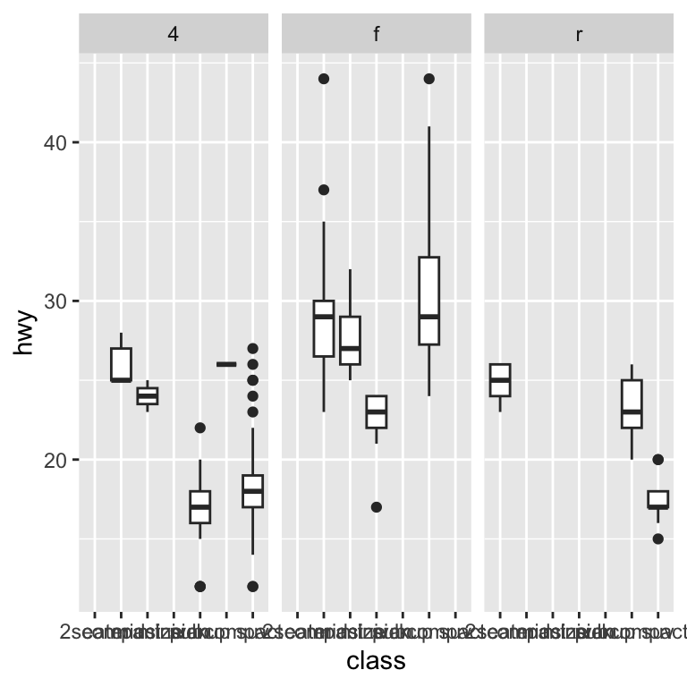

```r
 ggplot(mpg, aes(class, hwy)) +
  geom_boxplot() +
  facet_wrap(~drv)
```

## Question 4

Rather than geom_boxplot, add geom_jitter(height = 0.15) to create a plot with displ on the x axis and drv on the y axis. Add summaries for both mean (blue) and median (red).

```r
mpg <- as.data.frame(mpg)
head(mpg)
```

```
##   manufacturer model displ year cyl      trans drv cty hwy fl   class
## 1         audi    a4   1.8 1999   4   auto(l5)   f  18  29  p compact
## 2         audi    a4   1.8 1999   4 manual(m5)   f  21  29  p compact
## 3         audi    a4   2.0 2008   4 manual(m6)   f  20  31  p compact
## 4         audi    a4   2.0 2008   4   auto(av)   f  21  30  p compact
## 5         audi    a4   2.8 1999   6   auto(l5)   f  16  26  p compact
## 6         audi    a4   2.8 1999   6 manual(m5)   f  18  26  p compact
```

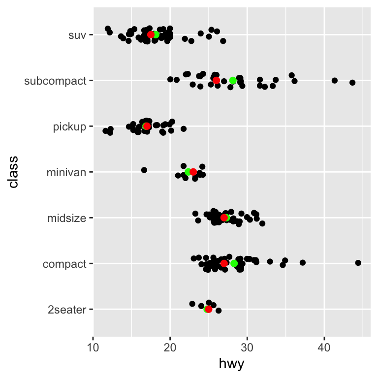

```r
ggplot(mpg, aes(hwy, class)) +
  geom_jitter(height = 0.15) +
  stat_summary(geom = "point", fun = "mean", color = "green", size = 2) +
  stat_summary(geom = "point", fun = "median", color = "red", size = 2)
```

## Question 5

Notice that in this section, we made several calls to layers that included arguments specifying visual aspects of the data (stat_summary(…, color = ‘red’, size = 2) and geom_jitter(height = 0.15)) without using the aes() function. Why did this still work? What impact did it have on the plots that were created?

This works because the `aes()` function is modifying the descriptive data of the graph as opposed to describing the data itself. The `stat_summary` function instead is adding to the graph, and the size and color are specific to that function. These params affect the stat summary and how easy it is to comprehend.

## Question 6

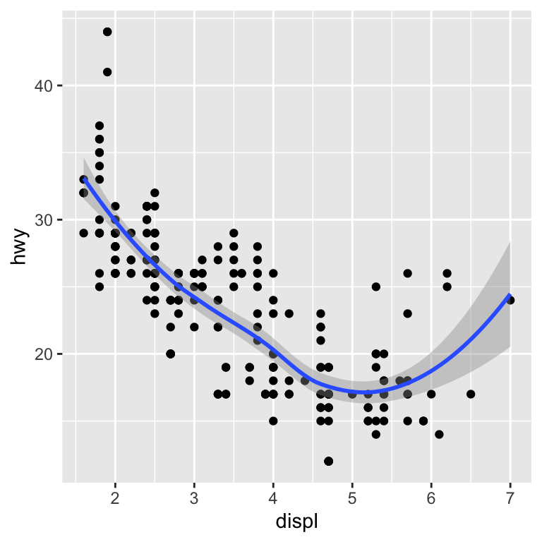

```r
ggplot(mpg, aes(displ, hwy)) +
  geom_point() +
  geom_smooth()
```

It was not running because the `aes()` function needs to be nested in `ggplot()` when there are multiple layers/concatenations using the `+` function.

## Question 7

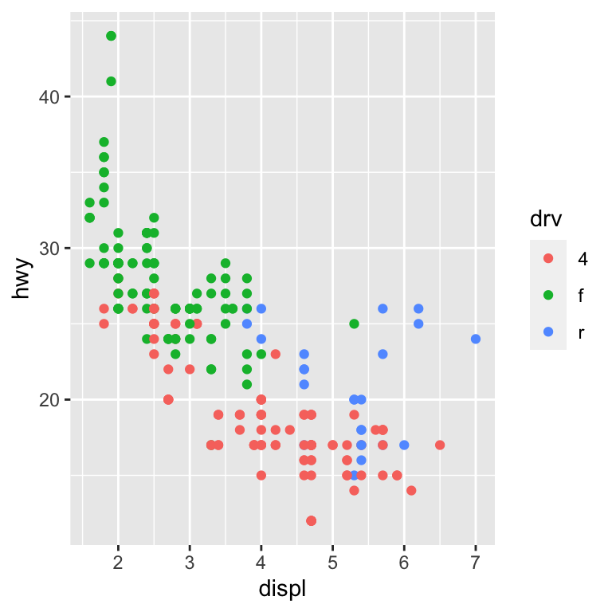

```r
ggplot(mpg, aes(displ, hwy)) +
  geom_point(aes(color = drv))
```

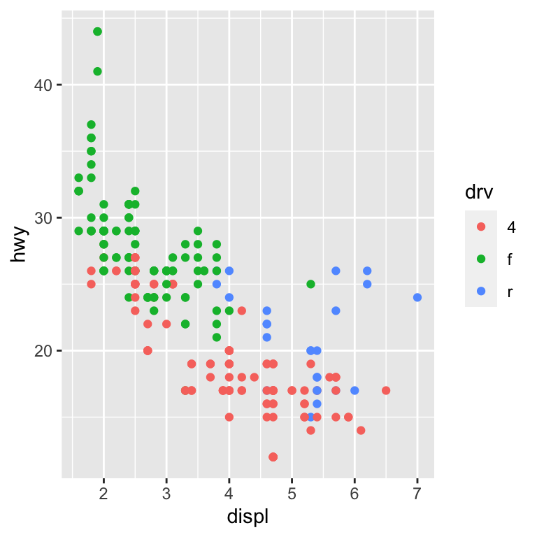

```r
ggplot(mpg, aes(displ, hwy, color = drv)) +
  geom_point()
```

The plots are visually identical. The only difference is in the nesting of the `aes()` function, which would be problematic if there were more layers in the second function.

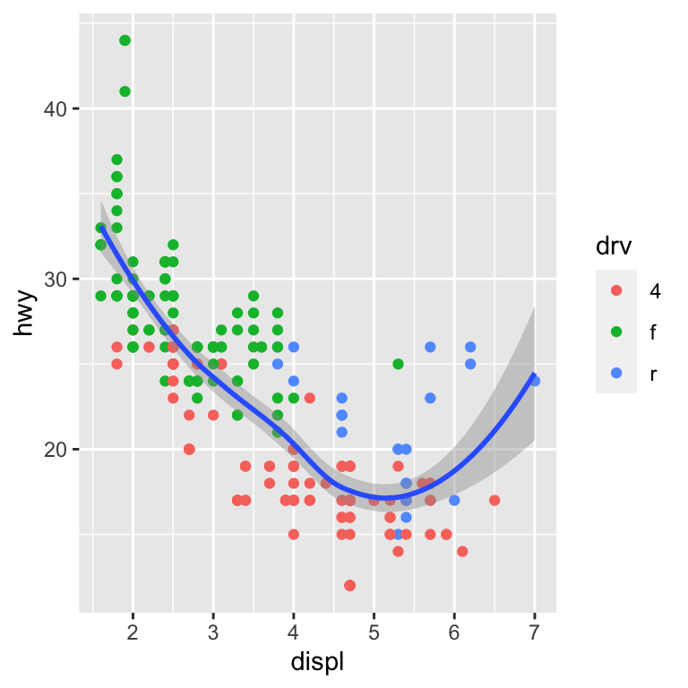

```r
## Plot 1
ggplot(mpg, aes(displ, hwy)) +
  geom_point(aes(color = drv)) +
  geom_smooth()
```

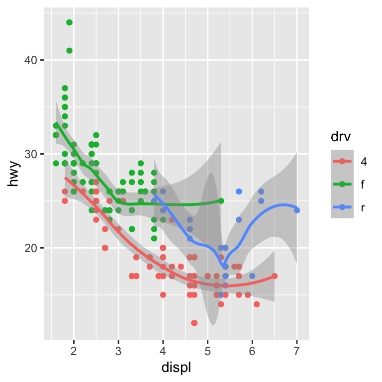

```r
## Plot 2
ggplot(mpg, aes(displ, hwy, color = drv)) +
  geom_point() +
  geom_smooth()
```

Plot 2 applies `aes(displ, hwy, color = drv)` to all three of the color mapped functions, which makes the data much more visually cluttered and challenging to understand.

## Question 8

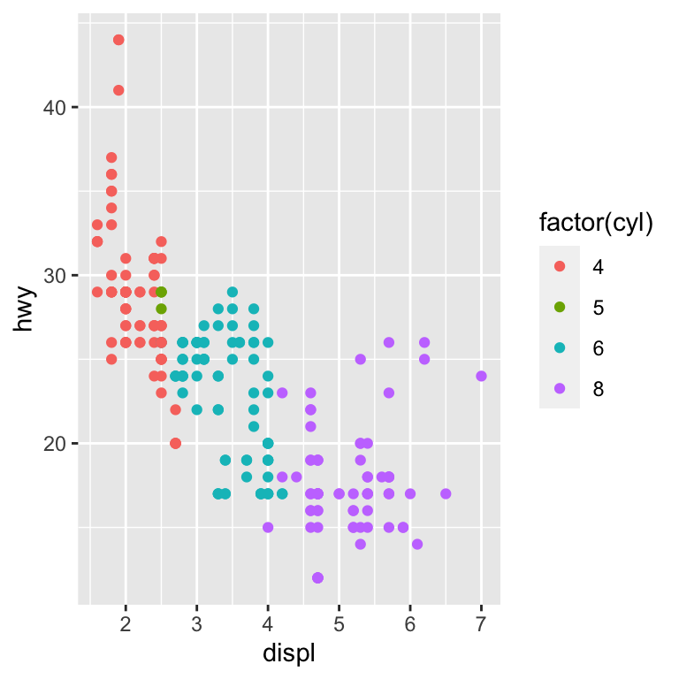

```r
ggplot(mpg, aes(displ, hwy, color = factor(cyl))) +
  geom_point()
```

## Question 9

This changes the structure of the color coding for cyl to be discrete instead of continuous. In this case, we don’t think that this is necessarily a good change, as a continuous variable would be a better representation of the data type.

## Question 10

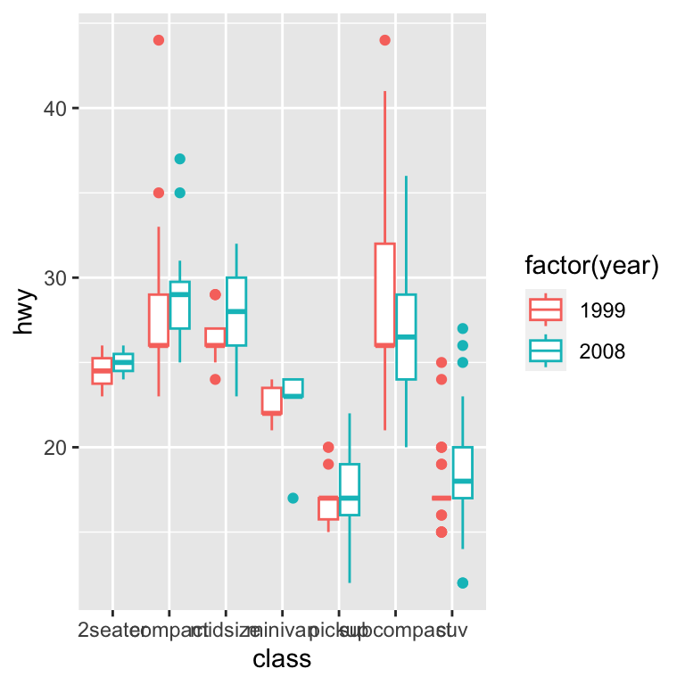

```r
ggplot(mpg, aes(class, hwy, color = factor(year))) +
  geom_boxplot(alpha = 1)
```

When we first ran it, we had issues with the coloring. We solved this by converting the year into a factor, according to the warning that R gave us! Great!

## Question 11

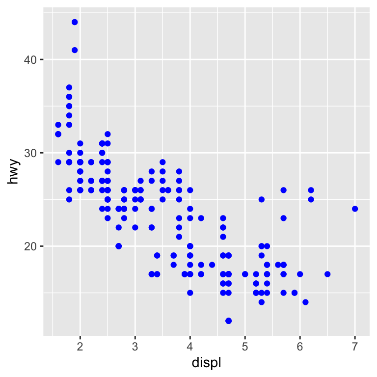

```r
ggplot(mpg, aes(displ, hwy)) +
  geom_point(color = "blue")
```

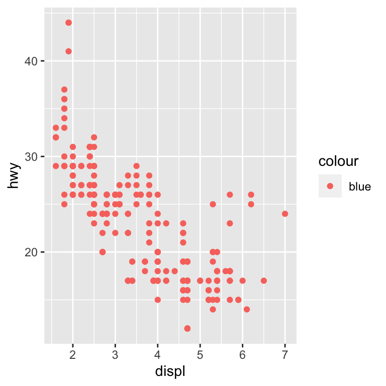

```r
ggplot(mpg, aes(displ, hwy)) +
  geom_point(aes(color = "blue"))
```

The first plot has blue points because the `color` arg modifies the points. However, in the second example the `aes()` function nested in the point generation is an addition layer, and that layer only has the information of `color = "blue"`, without any direction for what is supposed to be blue. Therefore it creates a key displaying this information to the best of the software’s abilities.

## Question 12

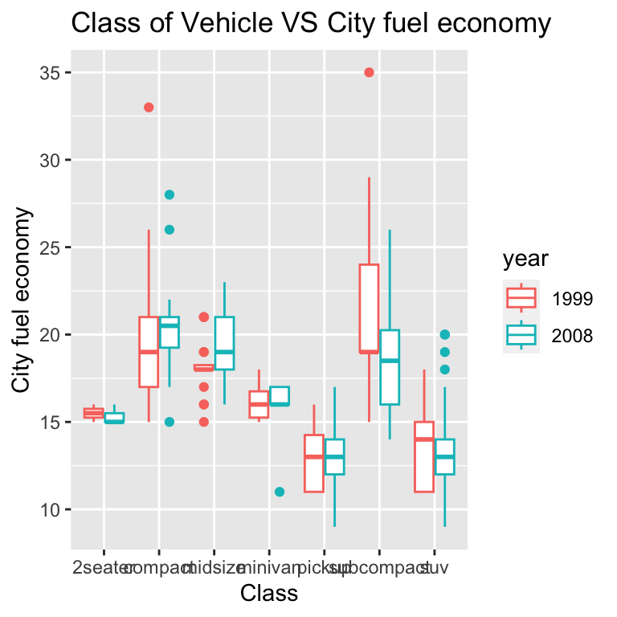

```r
ggplot(mpg, aes(class, cty, color = factor(year))) +
  geom_boxplot() +
  labs(x = "Class", y = "City fuel economy", title = "Class of Vehicle VS City fuel economy", color = "year")
```

## Example

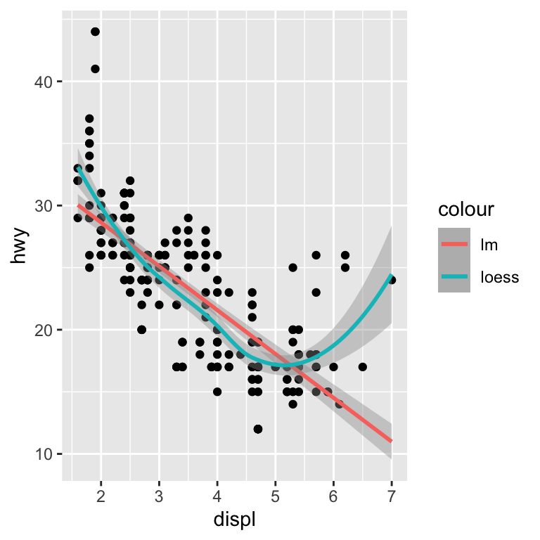

```r
ggplot(mpg, aes(displ, hwy)) +
  geom_point() +
  geom_smooth(aes(color = "lm"), method = "lm") +
  geom_smooth(aes(color = "loess"))
```

## Question 13

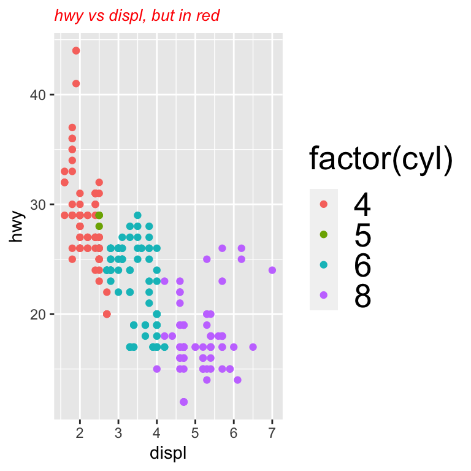

```r
ggplot(mpg, aes(displ, hwy, color = factor(cyl))) +
  geom_point() +
  labs(title = "hwy vs displ, but in red") +
  theme(plot.title = element_text(size = 10, color = "red", face = "italic"), legend.text = element_text(size = 20), legend.title = element_text(size = 20))
```

## Question 14

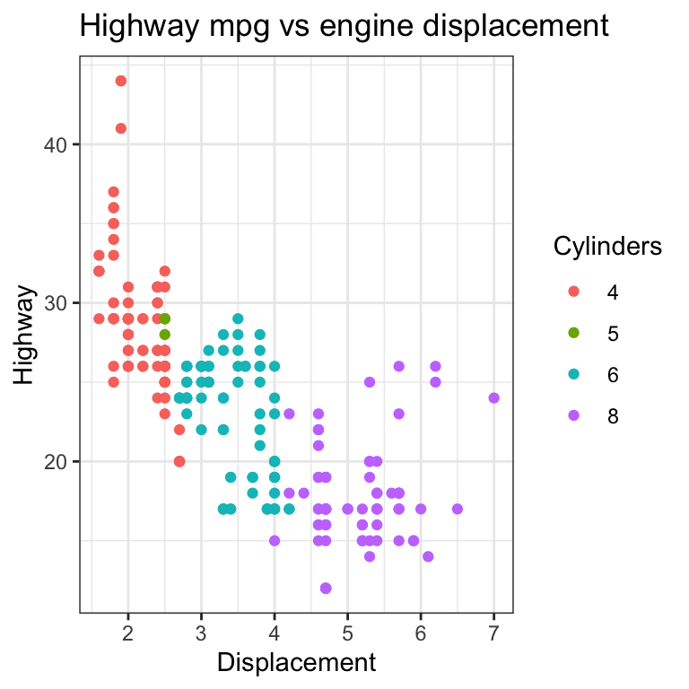

```r
ggplot(mpg, aes(displ, hwy, color = factor(cyl))) +
  geom_point() +
  labs(x = "Displacement", y = "Highway", title = "Highway mpg vs engine displacement", color = "Cylinders") +
  theme_bw() # adds a black and white theme
```

## Question 15

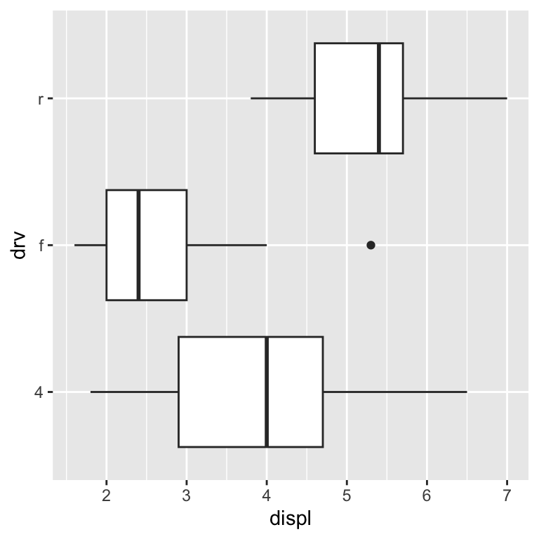

```r
ggplot(mpg, aes(displ, drv)) +
  geom_boxplot() +
    scale_x_continuous() +
  scale_y_discrete()
```

## Question 16

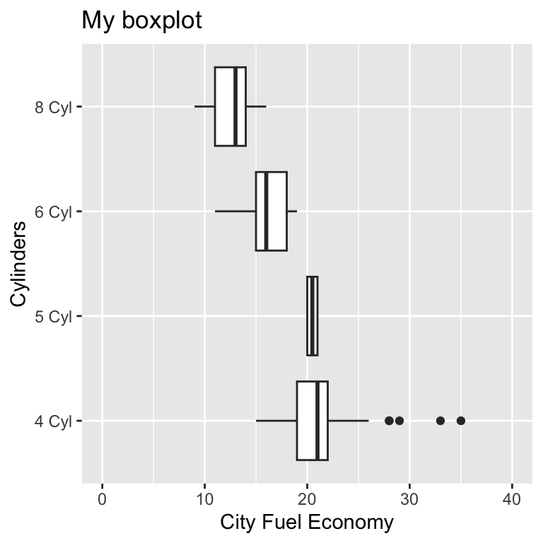

```r
ggplot(mpg, aes(cty, factor(cyl))) +
  geom_boxplot() +
  scale_y_discrete(labels = c(`8` = "8 Cyl", `6` = "6 Cyl", `5` = "5 Cyl", `4` = "4 Cyl" )) +
  scale_x_continuous(breaks = c(0, 10, 20, 30, 40), limits = c(0, 40)) +
  labs(x = "City Fuel Economy", y = "Cylinders", title = "My boxplot")
```

## Question 17

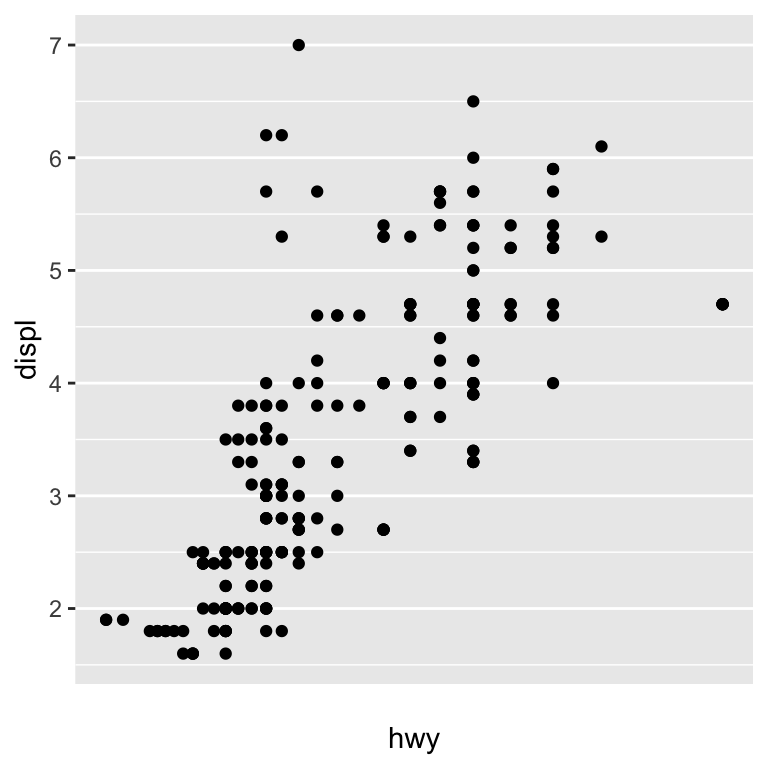

```r
ggplot(mpg, aes(hwy, displ)) +
  geom_point() +
  scale_x_continuous(trans = "reciprocal")
```

## Question 18

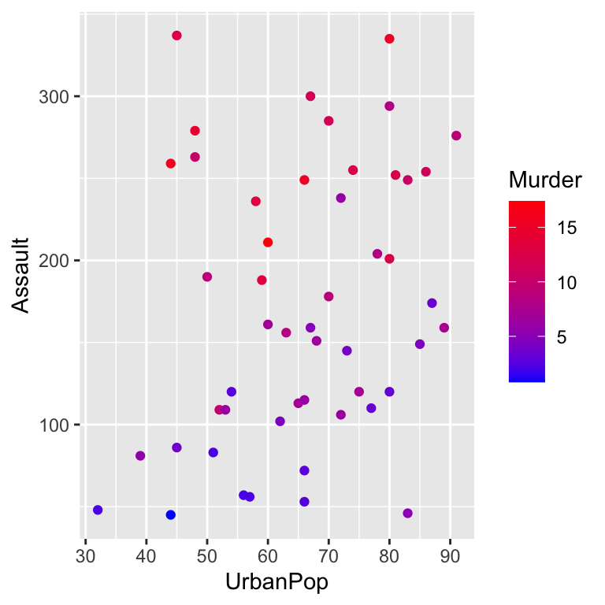

```r
ggplot(USArrests, aes(UrbanPop, Assault, color = Murder)) +
  geom_point() +
  scale_color_continuous(type = "gradient", high = "red", low = "blue")
```

It seems as though high rates of murder are more likely to correspond with high rates of assault rather than larger urban populations.

## Question 19

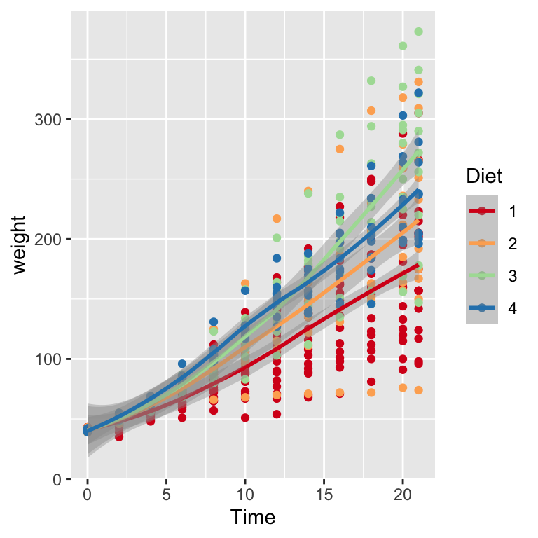

```r
ggplot(ChickWeight, aes(Time, weight, color = Diet)) +
  geom_point() +
  geom_smooth() +
  scale_color_brewer(palette = "Spectral")
```

Diet 3 seemed to result in chicks with the greatest average weight.

## Question 20

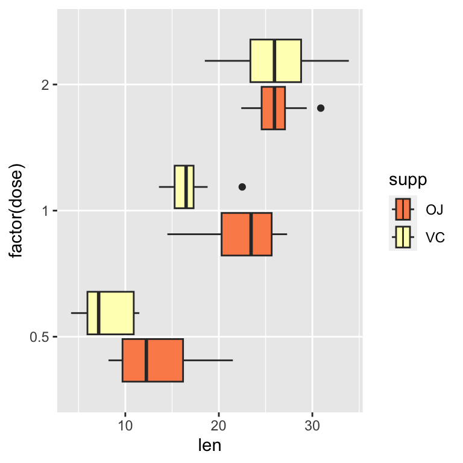

```r
ggplot(ToothGrowth, aes(len, factor(dose), fill = supp)) +
  geom_boxplot() +
  scale_fill_brewer(palette = "Spectral")
```

A higher dose of Vitamin C seems to be associated with increased tooth growth. Orange juice appears to be more effective at lower doses than the ascorbic acid, while at higher doses the tooth growth is similar between both.